# Risk Factor Analysis

## Outcome Variable

**Outcome Variable:** stunted

## Predictor Variables

**Intervention Variable:** meducyrs

**Adjustment Set:**

- arm
- W_mage
- feducyrs
- W_mhtcm
- W_gagebrth
- W_birthwt
- W_birthlen
- single
- impsan
- delta_W_mage
- delta_feducyrs
- delta_W_mhtcm
- delta_W_gagebrth
- delta_W_birthwt
- delta_W_birthlen
- delta_single
- delta_impsan

## Stratifying Variables

The analysis was stratified on these variable(s):

- agecat
- studyid
- country

## Data Summary

| agecat | studyid | country | meducyrs | stunted | n_cell | n |
| --- | --- | --- | --- | --- | --- | --- |
| Birth | ki0047075b-MAL-ED | BANGLADESH | Q4 | 0 | 55 | 207 |
| Birth | ki0047075b-MAL-ED | BANGLADESH | Q4 | 1 | 4 | 207 |
| Birth | ki0047075b-MAL-ED | BANGLADESH | Q1 | 0 | 28 | 207 |
| Birth | ki0047075b-MAL-ED | BANGLADESH | Q1 | 1 | 12 | 207 |
| Birth | ki0047075b-MAL-ED | BANGLADESH | Q2 | 0 | 23 | 207 |
| Birth | ki0047075b-MAL-ED | BANGLADESH | Q2 | 1 | 5 | 207 |
| Birth | ki0047075b-MAL-ED | BANGLADESH | Q3 | 0 | 65 | 207 |
| Birth | ki0047075b-MAL-ED | BANGLADESH | Q3 | 1 | 15 | 207 |
| 6 months | ki0047075b-MAL-ED | BANGLADESH | Q4 | 0 | 53 | 196 |
| 6 months | ki0047075b-MAL-ED | BANGLADESH | Q4 | 1 | 4 | 196 |
| 6 months | ki0047075b-MAL-ED | BANGLADESH | Q1 | 0 | 27 | 196 |
| 6 months | ki0047075b-MAL-ED | BANGLADESH | Q1 | 1 | 12 | 196 |
| 6 months | ki0047075b-MAL-ED | BANGLADESH | Q2 | 0 | 23 | 196 |
| 6 months | ki0047075b-MAL-ED | BANGLADESH | Q2 | 1 | 2 | 196 |
| 6 months | ki0047075b-MAL-ED | BANGLADESH | Q3 | 0 | 58 | 196 |
| 6 months | ki0047075b-MAL-ED | BANGLADESH | Q3 | 1 | 17 | 196 |
| 24 months | ki0047075b-MAL-ED | BANGLADESH | Q4 | 0 | 29 | 171 |
| 24 months | ki0047075b-MAL-ED | BANGLADESH | Q4 | 1 | 22 | 171 |
| 24 months | ki0047075b-MAL-ED | BANGLADESH | Q1 | 0 | 16 | 171 |
| 24 months | ki0047075b-MAL-ED | BANGLADESH | Q1 | 1 | 20 | 171 |
| 24 months | ki0047075b-MAL-ED | BANGLADESH | Q2 | 0 | 16 | 171 |
| 24 months | ki0047075b-MAL-ED | BANGLADESH | Q2 | 1 | 7 | 171 |
| 24 months | ki0047075b-MAL-ED | BANGLADESH | Q3 | 0 | 34 | 171 |
| 24 months | ki0047075b-MAL-ED | BANGLADESH | Q3 | 1 | 27 | 171 |
| Birth | ki0047075b-MAL-ED | BRAZIL | Q4 | 0 | 58 | 190 |
| Birth | ki0047075b-MAL-ED | BRAZIL | Q4 | 1 | 7 | 190 |
| Birth | ki0047075b-MAL-ED | BRAZIL | Q1 | 0 | 37 | 190 |
| Birth | ki0047075b-MAL-ED | BRAZIL | Q1 | 1 | 3 | 190 |
| Birth | ki0047075b-MAL-ED | BRAZIL | Q2 | 0 | 29 | 190 |
| Birth | ki0047075b-MAL-ED | BRAZIL | Q2 | 1 | 7 | 190 |

[output cut: 498 more lines]

The following strata were considered:

- agecat: 24 months, studyid: ki0047075b-MAL-ED, country: BANGLADESH
- agecat: 24 months, studyid: ki0047075b-MAL-ED, country: BRAZIL
- agecat: 24 months, studyid: ki0047075b-MAL-ED, country: INDIA
- agecat: 24 months, studyid: ki0047075b-MAL-ED, country: NEPAL
- agecat: 24 months, studyid: ki0047075b-MAL-ED, country: PERU
- agecat: 24 months, studyid: ki0047075b-MAL-ED, country: SOUTH AFRICA
- agecat: 24 months, studyid: ki0047075b-MAL-ED, country: TANZANIA, UNITED REPUBLIC OF
- agecat: 24 months, studyid: ki1000108-CMC-V-BCS-2002, country: INDIA
- agecat: 24 months, studyid: ki1000108-IRC, country: INDIA
- agecat: 24 months, studyid: ki1017093-NIH-Birth, country: BANGLADESH
- agecat: 24 months, studyid: ki1017093b-PROVIDE, country: BANGLADESH
- agecat: 24 months, studyid: ki1017093c-NIH-Crypto, country: BANGLADESH
- agecat: 24 months, studyid: ki1066203-TanzaniaChild2, country: TANZANIA, UNITED REPUBLIC OF
- agecat: 24 months, studyid: ki1113344-GMS-Nepal, country: NEPAL
- agecat: 24 months, studyid: ki1119695-PROBIT, country: BELARUS
- agecat: 24 months, studyid: ki1126311-ZVITAMBO, country: ZIMBABWE
- agecat: 24 months, studyid: ki1135781-COHORTS, country: GUATEMALA
- agecat: 24 months, studyid: ki1135781-COHORTS, country: INDIA
- agecat: 24 months, studyid: ki1135781-COHORTS, country: PHILIPPINES
- agecat: 24 months, studyid: ki1148112-LCNI-5, country: MALAWI
- agecat: 24 months, studyid: kiGH5241-JiVitA-3, country: BANGLADESH
- agecat: 24 months, studyid: kiGH5241-JiVitA-4, country: BANGLADESH
- agecat: 6 months, studyid: ki0047075b-MAL-ED, country: BANGLADESH
- agecat: 6 months, studyid: ki0047075b-MAL-ED, country: BRAZIL
- agecat: 6 months, studyid: ki0047075b-MAL-ED, country: INDIA
- agecat: 6 months, studyid: ki0047075b-MAL-ED, country: NEPAL
- agecat: 6 months, studyid: ki0047075b-MAL-ED, country: PERU
- agecat: 6 months, studyid: ki0047075b-MAL-ED, country: SOUTH AFRICA
- agecat: 6 months, studyid: ki0047075b-MAL-ED, country: TANZANIA, UNITED REPUBLIC OF
- agecat: 6 months, studyid: ki1000108-CMC-V-BCS-2002, country: INDIA
- agecat: 6 months, studyid: ki1000108-IRC, country: INDIA
- agecat: 6 months, studyid: ki1000109-EE, country: PAKISTAN
- agecat: 6 months, studyid: ki1000304b-SAS-CompFeed, country: INDIA
- agecat: 6 months, studyid: ki1000304b-SAS-FoodSuppl, country: INDIA
- agecat: 6 months, studyid: ki1017093-NIH-Birth, country: BANGLADESH
- agecat: 6 months, studyid: ki1017093b-PROVIDE, country: BANGLADESH
- agecat: 6 months, studyid: ki1017093c-NIH-Crypto, country: BANGLADESH
- agecat: 6 months, studyid: ki1066203-TanzaniaChild2, country: TANZANIA, UNITED REPUBLIC OF
- agecat: 6 months, studyid: ki1112895-Guatemala BSC, country: GUATEMALA
- agecat: 6 months, studyid: ki1113344-GMS-Nepal, country: NEPAL
- agecat: 6 months, studyid: ki1119695-PROBIT, country: BELARUS
- agecat: 6 months, studyid: ki1126311-ZVITAMBO, country: ZIMBABWE
- agecat: 6 months, studyid: ki1135781-COHORTS, country: GUATEMALA
- agecat: 6 months, studyid: ki1135781-COHORTS, country: INDIA
- agecat: 6 months, studyid: ki1135781-COHORTS, country: PHILIPPINES
- agecat: 6 months, studyid: ki1148112-LCNI-5, country: MALAWI
- agecat: 6 months, studyid: kiGH5241-JiVitA-3, country: BANGLADESH
- agecat: 6 months, studyid: kiGH5241-JiVitA-4, country: BANGLADESH
- agecat: Birth, studyid: ki0047075b-MAL-ED, country: BANGLADESH
- agecat: Birth, studyid: ki0047075b-MAL-ED, country: BRAZIL
- agecat: Birth, studyid: ki0047075b-MAL-ED, country: INDIA
- agecat: Birth, studyid: ki0047075b-MAL-ED, country: NEPAL
- agecat: Birth, studyid: ki0047075b-MAL-ED, country: PERU
- agecat: Birth, studyid: ki0047075b-MAL-ED, country: SOUTH AFRICA
- agecat: Birth, studyid: ki0047075b-MAL-ED, country: TANZANIA, UNITED REPUBLIC OF
- agecat: Birth, studyid: ki1000108-CMC-V-BCS-2002, country: INDIA
- agecat: Birth, studyid: ki1000108-IRC, country: INDIA
- agecat: Birth, studyid: ki1000109-EE, country: PAKISTAN
- agecat: Birth, studyid: ki1000304b-SAS-CompFeed, country: INDIA
- agecat: Birth, studyid: ki1017093-NIH-Birth, country: BANGLADESH
- agecat: Birth, studyid: ki1017093c-NIH-Crypto, country: BANGLADESH
- agecat: Birth, studyid: ki1119695-PROBIT, country: BELARUS
- agecat: Birth, studyid: ki1126311-ZVITAMBO, country: ZIMBABWE
- agecat: Birth, studyid: ki1135781-COHORTS, country: GUATEMALA
- agecat: Birth, studyid: ki1135781-COHORTS, country: INDIA
- agecat: Birth, studyid: ki1135781-COHORTS, country: PHILIPPINES
- agecat: Birth, studyid: kiGH5241-JiVitA-3, country: BANGLADESH
- agecat: Birth, studyid: kiGH5241-JiVitA-4, country: BANGLADESH

### Dropped Strata

Some strata were dropped due to rare outcomes:

- agecat: Birth, studyid: ki0047075b-MAL-ED, country: BANGLADESH
- agecat: 6 months, studyid: ki0047075b-MAL-ED, country: BANGLADESH
- agecat: Birth, studyid: ki0047075b-MAL-ED, country: BRAZIL
- agecat: 6 months, studyid: ki0047075b-MAL-ED, country: BRAZIL
- agecat: 24 months, studyid: ki0047075b-MAL-ED, country: BRAZIL
- agecat: Birth, studyid: ki0047075b-MAL-ED, country: INDIA
- agecat: Birth, studyid: ki0047075b-MAL-ED, country: NEPAL
- agecat: 6 months, studyid: ki0047075b-MAL-ED, country: NEPAL
- agecat: 24 months, studyid: ki0047075b-MAL-ED, country: NEPAL
- agecat: Birth, studyid: ki0047075b-MAL-ED, country: SOUTH AFRICA
- agecat: Birth, studyid: ki0047075b-MAL-ED, country: TANZANIA, UNITED REPUBLIC OF
- agecat: 6 months, studyid: ki0047075b-MAL-ED, country: TANZANIA, UNITED REPUBLIC OF
- agecat: 24 months, studyid: ki0047075b-MAL-ED, country: TANZANIA, UNITED REPUBLIC OF
- agecat: Birth, studyid: ki1000108-CMC-V-BCS-2002, country: INDIA
- agecat: 6 months, studyid: ki1000108-IRC, country: INDIA
- agecat: 24 months, studyid: ki1000108-IRC, country: INDIA
- agecat: Birth, studyid: ki1000108-IRC, country: INDIA
- agecat: 6 months, studyid: ki1000109-EE, country: PAKISTAN
- agecat: Birth, studyid: ki1000109-EE, country: PAKISTAN
- agecat: Birth, studyid: ki1000304b-SAS-CompFeed, country: INDIA
- agecat: 6 months, studyid: ki1000304b-SAS-FoodSuppl, country: INDIA
- agecat: Birth, studyid: ki1017093-NIH-Birth, country: BANGLADESH
- agecat: 6 months, studyid: ki1017093b-PROVIDE, country: BANGLADESH
- agecat: 24 months, studyid: ki1017093b-PROVIDE, country: BANGLADESH
- agecat: Birth, studyid: ki1017093c-NIH-Crypto, country: BANGLADESH
- agecat: 6 months, studyid: ki1066203-TanzaniaChild2, country: TANZANIA, UNITED REPUBLIC OF
- agecat: 24 months, studyid: ki1066203-TanzaniaChild2, country: TANZANIA, UNITED REPUBLIC OF
- agecat: Birth, studyid: ki1119695-PROBIT, country: BELARUS
- agecat: 24 months, studyid: ki1126311-ZVITAMBO, country: ZIMBABWE
- agecat: 24 months, studyid: ki1135781-COHORTS, country: GUATEMALA
- agecat: 6 months, studyid: ki1135781-COHORTS, country: GUATEMALA
- agecat: Birth, studyid: ki1135781-COHORTS, country: GUATEMALA
- agecat: 6 months, studyid: ki1148112-LCNI-5, country: MALAWI
- agecat: 24 months, studyid: ki1148112-LCNI-5, country: MALAWI
- agecat: Birth, studyid: kiGH5241-JiVitA-4, country: BANGLADESH

## Methods Detail

We’re interested in the causal parameters $E[Y_a]$ for all values of $a \in \mathcal{A}$. These parameters represent the mean outcome if, possibly contrary to fact, we intervened to set all units to have $A=a$. Under the randomization and positivity assumptions, these are identified by the statistical parameters $\psi_a=E_W[E_{Y|A,W}(Y|A=a,W)]$. In addition, we’re interested in the mean of $Y$, $E[Y]$ under no intervention (the observed mean). We will estimate these parameters by using SuperLearner to fit the relevant likelihood factors – $E_{Y|A,W}(Y|A=a,W)$ and $p(A=a|W)$, and then updating our likelihood fit using a joint TMLE.

For unadjusted analyses ($W=\{\}$), initial likelihoods were estimated using Lrnr_glm to estimate the simple $E(Y|A)$ and Lrnr_mean to estimate $p(A)$. For adjusted analyses, a small library containing Lrnr_glmnet, Lrnr_xgboost, and Lrnr_mean was used.

Having estimated these parameters, we will then use the delta method to estimate relative risks and attributable risks relative to a prespecified baseline level of $A$.

[output not shown]

# Results Detail

## Results Plots

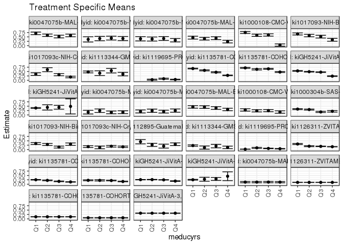

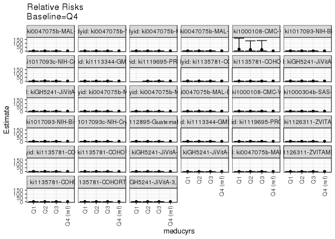

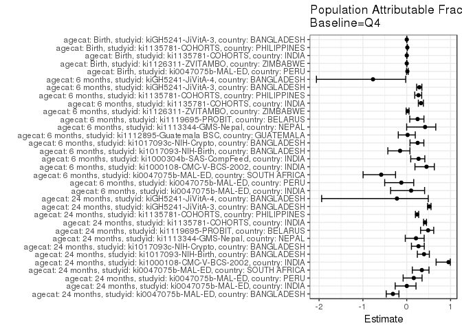

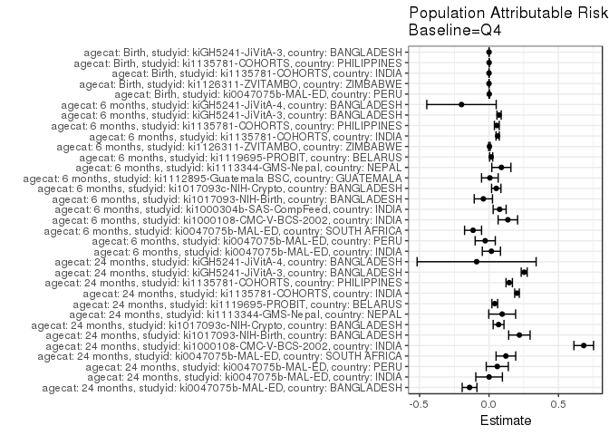

## Results Table

### Parameter: TSM

| agecat | studyid | country | intervention_level | baseline_level | estimate | ci_lower | ci_upper |
| --- | --- | --- | --- | --- | --- | --- | --- |
| Birth | ki0047075b-MAL-ED | PERU | Q4 | NA | 0.1171745 | 0.0800576 | 0.1542914 |
| Birth | ki0047075b-MAL-ED | PERU | Q1 | NA | 0.1189660 | 0.0813831 | 0.1565488 |
| Birth | ki0047075b-MAL-ED | PERU | Q2 | NA | 0.1190664 | 0.0815357 | 0.1565972 |
| Birth | ki0047075b-MAL-ED | PERU | Q3 | NA | 0.1199733 | 0.0824020 | 0.1575445 |
| Birth | ki1126311-ZVITAMBO | ZIMBABWE | Q4 | NA | 0.1036784 | 0.0985944 | 0.1087624 |
| Birth | ki1126311-ZVITAMBO | ZIMBABWE | Q1 | NA | 0.1038244 | 0.0987451 | 0.1089037 |
| Birth | ki1126311-ZVITAMBO | ZIMBABWE | Q2 | NA | 0.1036670 | 0.0985854 | 0.1087486 |
| Birth | ki1126311-ZVITAMBO | ZIMBABWE | Q3 | NA | 0.1036876 | 0.0986033 | 0.1087720 |
| Birth | ki1135781-COHORTS | INDIA | Q4 | NA | 0.1181725 | 0.1094166 | 0.1269284 |
| Birth | ki1135781-COHORTS | INDIA | Q1 | NA | 0.1182436 | 0.1094825 | 0.1270047 |
| Birth | ki1135781-COHORTS | INDIA | Q2 | NA | 0.1182352 | 0.1094751 | 0.1269954 |
| Birth | ki1135781-COHORTS | INDIA | Q3 | NA | 0.1182338 | 0.1094741 | 0.1269936 |
| Birth | ki1135781-COHORTS | PHILIPPINES | Q4 | NA | 0.0605142 | 0.0521083 | 0.0689202 |
| Birth | ki1135781-COHORTS | PHILIPPINES | Q1 | NA | 0.0607102 | 0.0522745 | 0.0691460 |
| Birth | ki1135781-COHORTS | PHILIPPINES | Q2 | NA | 0.0601983 | 0.0518292 | 0.0685675 |
| Birth | ki1135781-COHORTS | PHILIPPINES | Q3 | NA | 0.0610170 | 0.0525404 | 0.0694936 |
| Birth | kiGH5241-JiVitA-3 | BANGLADESH | Q4 | NA | 0.3231203 | 0.3154666 | 0.3307740 |
| Birth | kiGH5241-JiVitA-3 | BANGLADESH | Q1 | NA | 0.3232756 | 0.3156180 | 0.3309332 |
| Birth | kiGH5241-JiVitA-3 | BANGLADESH | Q2 | NA | 0.3232700 | 0.3156124 | 0.3309276 |
| Birth | kiGH5241-JiVitA-3 | BANGLADESH | Q3 | NA | 0.3232635 | 0.3156057 | 0.3309212 |
| 6 months | ki0047075b-MAL-ED | INDIA | Q4 | NA | 0.1558362 | 0.0758560 | 0.2358165 |
| 6 months | ki0047075b-MAL-ED | INDIA | Q1 | NA | 0.1589997 | 0.0531713 | 0.2648282 |
| 6 months | ki0047075b-MAL-ED | INDIA | Q2 | NA | 0.2389878 | 0.1373367 | 0.3406389 |
| 6 months | ki0047075b-MAL-ED | INDIA | Q3 | NA | 0.1452351 | 0.0680462 | 0.2224239 |
| 6 months | ki0047075b-MAL-ED | PERU | Q4 | NA | 0.2479264 | 0.1555220 | 0.3403308 |
| 6 months | ki0047075b-MAL-ED | PERU | Q1 | NA | 0.1987038 | 0.1112710 | 0.2861366 |
| 6 months | ki0047075b-MAL-ED | PERU | Q2 | NA | 0.2399298 | 0.1465909 | 0.3332686 |
| 6 months | ki0047075b-MAL-ED | PERU | Q3 | NA | 0.1892657 | 0.1071662 | 0.2713651 |
| 6 months | ki0047075b-MAL-ED | SOUTH AFRICA | Q4 | NA | 0.3115998 | 0.2408303 | 0.3823694 |
| 6 months | ki0047075b-MAL-ED | SOUTH AFRICA | Q1 | NA | 0.4591402 | 0.3879997 | 0.5302807 |

[output cut: 101 more lines]

### Parameter: E(Y)

| agecat | studyid | country | intervention_level | baseline_level | estimate | ci_lower | ci_upper |
| --- | --- | --- | --- | --- | --- | --- | --- |
| Birth | ki0047075b-MAL-ED | PERU | NA | NA | 0.1188811 | 0.0813061 | 0.1564562 |
| Birth | ki1126311-ZVITAMBO | ZIMBABWE | NA | NA | 0.1036930 | 0.0986082 | 0.1087777 |
| Birth | ki1135781-COHORTS | INDIA | NA | NA | 0.1182899 | 0.1095248 | 0.1270550 |
| Birth | ki1135781-COHORTS | PHILIPPINES | NA | NA | 0.0613115 | 0.0527962 | 0.0698268 |
| Birth | kiGH5241-JiVitA-3 | BANGLADESH | NA | NA | 0.3232756 | 0.3156176 | 0.3309337 |
| 6 months | ki0047075b-MAL-ED | INDIA | NA | NA | 0.1730769 | 0.1215404 | 0.2246134 |
| 6 months | ki0047075b-MAL-ED | PERU | NA | NA | 0.2205882 | 0.1712211 | 0.2699554 |
| 6 months | ki0047075b-MAL-ED | SOUTH AFRICA | NA | NA | 0.1968504 | 0.1478551 | 0.2458457 |
| 6 months | ki1000108-CMC-V-BCS-2002 | INDIA | NA | NA | 0.3008130 | 0.2539566 | 0.3476694 |
| 6 months | ki1000304b-SAS-CompFeed | INDIA | NA | NA | 0.2844311 | 0.2666491 | 0.3022132 |
| 6 months | ki1017093-NIH-Birth | BANGLADESH | NA | NA | 0.2681564 | 0.2306532 | 0.3056597 |
| 6 months | ki1017093c-NIH-Crypto | BANGLADESH | NA | NA | 0.2097902 | 0.1799252 | 0.2396552 |
| 6 months | ki1112895-Guatemala BSC | GUATEMALA | NA | NA | 0.3104693 | 0.2558835 | 0.3650551 |
| 6 months | ki1113344-GMS-Nepal | NEPAL | NA | NA | 0.2125000 | 0.1785885 | 0.2464115 |
| 6 months | ki1119695-PROBIT | BELARUS | NA | NA | 0.0626864 | 0.0488489 | 0.0765238 |
| 6 months | ki1126311-ZVITAMBO | ZIMBABWE | NA | NA | 0.1665057 | 0.1584820 | 0.1745293 |
| 6 months | ki1135781-COHORTS | INDIA | NA | NA | 0.1915758 | 0.1810911 | 0.2020606 |
| 6 months | ki1135781-COHORTS | PHILIPPINES | NA | NA | 0.2112260 | 0.1958496 | 0.2266024 |
| 6 months | kiGH5241-JiVitA-3 | BANGLADESH | NA | NA | 0.2514589 | 0.2433251 | 0.2595926 |
| 6 months | kiGH5241-JiVitA-4 | BANGLADESH | NA | NA | 0.2573674 | 0.2348896 | 0.2798452 |
| 24 months | ki0047075b-MAL-ED | BANGLADESH | NA | NA | 0.4444444 | 0.3697487 | 0.5191402 |
| 24 months | ki0047075b-MAL-ED | INDIA | NA | NA | 0.4070352 | 0.3386053 | 0.4754651 |
| 24 months | ki0047075b-MAL-ED | PERU | NA | NA | 0.3700000 | 0.3029201 | 0.4370799 |
| 24 months | ki0047075b-MAL-ED | SOUTH AFRICA | NA | NA | 0.3529412 | 0.2921001 | 0.4137823 |
| 24 months | ki1000108-CMC-V-BCS-2002 | INDIA | NA | NA | 0.7150538 | 0.6691221 | 0.7609854 |
| 24 months | ki1017093-NIH-Birth | BANGLADESH | NA | NA | 0.5547786 | 0.5076945 | 0.6018626 |
| 24 months | ki1017093c-NIH-Crypto | BANGLADESH | NA | NA | 0.2568093 | 0.2190047 | 0.2946140 |
| 24 months | ki1113344-GMS-Nepal | NEPAL | NA | NA | 0.4495968 | 0.4057742 | 0.4934193 |
| 24 months | ki1119695-PROBIT | BELARUS | NA | NA | 0.0852540 | 0.0554439 | 0.1150642 |
| 24 months | ki1135781-COHORTS | INDIA | NA | NA | 0.4815520 | 0.4664409 | 0.4966632 |
| 24 months | ki1135781-COHORTS | PHILIPPINES | NA | NA | 0.6167689 | 0.5974942 | 0.6360437 |
| 24 months | kiGH5241-JiVitA-3 | BANGLADESH | NA | NA | 0.4907783 | 0.4776560 | 0.5039007 |
| 24 months | kiGH5241-JiVitA-4 | BANGLADESH | NA | NA | 0.3988036 | 0.3729992 | 0.4246080 |

### Parameter: RR

| agecat | studyid | country | intervention_level | baseline_level | estimate | ci_lower | ci_upper |
| --- | --- | --- | --- | --- | --- | --- | --- |
| Birth | ki0047075b-MAL-ED | PERU | Q4 | Q4 | 1.0000000 | 1.0000000 | 1.0000000 |
| Birth | ki0047075b-MAL-ED | PERU | Q1 | Q4 | 1.0152890 | 0.9964471 | 1.0344871 |
| Birth | ki0047075b-MAL-ED | PERU | Q2 | Q4 | 1.0161463 | 0.9954850 | 1.0372364 |
| Birth | ki0047075b-MAL-ED | PERU | Q3 | Q4 | 1.0238854 | 0.9998822 | 1.0484647 |
| Birth | ki1126311-ZVITAMBO | ZIMBABWE | Q4 | Q4 | 1.0000000 | 1.0000000 | 1.0000000 |
| Birth | ki1126311-ZVITAMBO | ZIMBABWE | Q1 | Q4 | 1.0014082 | 1.0007597 | 1.0020571 |
| Birth | ki1126311-ZVITAMBO | ZIMBABWE | Q2 | Q4 | 0.9998901 | 0.9996959 | 1.0000844 |
| Birth | ki1126311-ZVITAMBO | ZIMBABWE | Q3 | Q4 | 1.0000888 | 0.9999768 | 1.0002008 |
| Birth | ki1135781-COHORTS | INDIA | Q4 | Q4 | 1.0000000 | 1.0000000 | 1.0000000 |
| Birth | ki1135781-COHORTS | INDIA | Q1 | Q4 | 1.0006018 | 1.0002749 | 1.0009288 |
| Birth | ki1135781-COHORTS | INDIA | Q2 | Q4 | 1.0005311 | 1.0001741 | 1.0008882 |
| Birth | ki1135781-COHORTS | INDIA | Q3 | Q4 | 1.0005193 | 1.0001717 | 1.0008671 |
| Birth | ki1135781-COHORTS | PHILIPPINES | Q4 | Q4 | 1.0000000 | 1.0000000 | 1.0000000 |
| Birth | ki1135781-COHORTS | PHILIPPINES | Q1 | Q4 | 1.0032388 | 0.9991365 | 1.0073580 |
| Birth | ki1135781-COHORTS | PHILIPPINES | Q2 | Q4 | 0.9947798 | 0.9890681 | 1.0005244 |
| Birth | ki1135781-COHORTS | PHILIPPINES | Q3 | Q4 | 1.0083084 | 1.0050893 | 1.0115378 |
| Birth | kiGH5241-JiVitA-3 | BANGLADESH | Q4 | Q4 | 1.0000000 | 1.0000000 | 1.0000000 |
| Birth | kiGH5241-JiVitA-3 | BANGLADESH | Q1 | Q4 | 1.0004807 | 1.0004380 | 1.0005235 |
| Birth | kiGH5241-JiVitA-3 | BANGLADESH | Q2 | Q4 | 1.0004634 | 1.0004194 | 1.0005073 |
| Birth | kiGH5241-JiVitA-3 | BANGLADESH | Q3 | Q4 | 1.0004431 | 1.0003995 | 1.0004867 |
| 6 months | ki0047075b-MAL-ED | INDIA | Q4 | Q4 | 1.0000000 | 1.0000000 | 1.0000000 |
| 6 months | ki0047075b-MAL-ED | INDIA | Q1 | Q4 | 1.0203003 | 0.4570202 | 2.2778263 |
| 6 months | ki0047075b-MAL-ED | INDIA | Q2 | Q4 | 1.5335829 | 0.8161040 | 2.8818345 |
| 6 months | ki0047075b-MAL-ED | INDIA | Q3 | Q4 | 0.9319725 | 0.4664184 | 1.8622179 |
| 6 months | ki0047075b-MAL-ED | PERU | Q4 | Q4 | 1.0000000 | 1.0000000 | 1.0000000 |
| 6 months | ki0047075b-MAL-ED | PERU | Q1 | Q4 | 0.8014629 | 0.4578317 | 1.4030109 |
| 6 months | ki0047075b-MAL-ED | PERU | Q2 | Q4 | 0.9677460 | 0.5733448 | 1.6334541 |
| 6 months | ki0047075b-MAL-ED | PERU | Q3 | Q4 | 0.7633948 | 0.4373577 | 1.3324826 |
| 6 months | ki0047075b-MAL-ED | SOUTH AFRICA | Q4 | Q4 | 1.0000000 | 1.0000000 | 1.0000000 |
| 6 months | ki0047075b-MAL-ED | SOUTH AFRICA | Q1 | Q4 | 1.4734932 | 1.1309586 | 1.9197715 |

[output cut: 101 more lines]

### Parameter: PAR

| agecat | studyid | country | intervention_level | baseline_level | estimate | ci_lower | ci_upper |
| --- | --- | --- | --- | --- | --- | --- | --- |
| Birth | ki0047075b-MAL-ED | PERU | Q4 | NA | 0.0017066 | -0.0005562 | 0.0039694 |
| Birth | ki1126311-ZVITAMBO | ZIMBABWE | Q4 | NA | 0.0000146 | 0.0000094 | 0.0000197 |
| Birth | ki1135781-COHORTS | INDIA | Q4 | NA | 0.0001174 | 0.0000878 | 0.0001470 |
| Birth | ki1135781-COHORTS | PHILIPPINES | Q4 | NA | 0.0007972 | 0.0006133 | 0.0009812 |
| Birth | kiGH5241-JiVitA-3 | BANGLADESH | Q4 | NA | 0.0001554 | 0.0001417 | 0.0001690 |
| 6 months | ki0047075b-MAL-ED | INDIA | Q4 | NA | 0.0172407 | -0.0481812 | 0.0826625 |
| 6 months | ki0047075b-MAL-ED | PERU | Q4 | NA | -0.0273381 | -0.0998651 | 0.0451888 |
| 6 months | ki0047075b-MAL-ED | SOUTH AFRICA | Q4 | NA | -0.1147494 | -0.1759409 | -0.0535579 |
| 6 months | ki1000108-CMC-V-BCS-2002 | INDIA | Q4 | NA | 0.1357514 | 0.0655835 | 0.2059193 |
| 6 months | ki1000304b-SAS-CompFeed | INDIA | Q4 | NA | 0.0765827 | 0.0298732 | 0.1232923 |
| 6 months | ki1017093-NIH-Birth | BANGLADESH | Q4 | NA | -0.0407470 | -0.1064738 | 0.0249798 |
| 6 months | ki1017093c-NIH-Crypto | BANGLADESH | Q4 | NA | 0.0522527 | 0.0185918 | 0.0859136 |
| 6 months | ki1112895-Guatemala BSC | GUATEMALA | Q4 | NA | 0.0062107 | -0.0537013 | 0.0661226 |
| 6 months | ki1113344-GMS-Nepal | NEPAL | Q4 | NA | 0.0889619 | 0.0202359 | 0.1576879 |
| 6 months | ki1119695-PROBIT | BELARUS | Q4 | NA | 0.0155304 | 0.0043701 | 0.0266907 |
| 6 months | ki1126311-ZVITAMBO | ZIMBABWE | Q4 | NA | 0.0032718 | -0.0023022 | 0.0088458 |
| 6 months | ki1135781-COHORTS | INDIA | Q4 | NA | 0.0622390 | 0.0505866 | 0.0738914 |
| 6 months | ki1135781-COHORTS | PHILIPPINES | Q4 | NA | 0.0563281 | 0.0389084 | 0.0737478 |
| 6 months | kiGH5241-JiVitA-3 | BANGLADESH | Q4 | NA | 0.0724852 | 0.0572985 | 0.0876718 |
| 6 months | kiGH5241-JiVitA-4 | BANGLADESH | Q4 | NA | -0.1981695 | -0.4482110 | 0.0518720 |
| 24 months | ki0047075b-MAL-ED | BANGLADESH | Q4 | NA | -0.1399890 | -0.1930746 | -0.0869035 |
| 24 months | ki0047075b-MAL-ED | INDIA | Q4 | NA | 0.0006905 | -0.0950825 | 0.0964634 |
| 24 months | ki0047075b-MAL-ED | PERU | Q4 | NA | 0.0595744 | -0.0198328 | 0.1389816 |
| 24 months | ki0047075b-MAL-ED | SOUTH AFRICA | Q4 | NA | 0.1215467 | 0.0508838 | 0.1922096 |
| 24 months | ki1000108-CMC-V-BCS-2002 | INDIA | Q4 | NA | 0.6821937 | 0.6115035 | 0.7528839 |
| 24 months | ki1017093-NIH-Birth | BANGLADESH | Q4 | NA | 0.2188356 | 0.1417297 | 0.2959415 |
| 24 months | ki1017093c-NIH-Crypto | BANGLADESH | Q4 | NA | 0.0687950 | 0.0297506 | 0.1078394 |
| 24 months | ki1113344-GMS-Nepal | NEPAL | Q4 | NA | 0.0949558 | -0.0016980 | 0.1916096 |
| 24 months | ki1119695-PROBIT | BELARUS | Q4 | NA | 0.0415404 | 0.0208507 | 0.0622300 |
| 24 months | ki1135781-COHORTS | INDIA | Q4 | NA | 0.2016047 | 0.1850366 | 0.2181729 |
| 24 months | ki1135781-COHORTS | PHILIPPINES | Q4 | NA | 0.1455185 | 0.1225429 | 0.1684941 |
| 24 months | kiGH5241-JiVitA-3 | BANGLADESH | Q4 | NA | 0.2532772 | 0.2318100 | 0.2747444 |
| 24 months | kiGH5241-JiVitA-4 | BANGLADESH | Q4 | NA | -0.0891401 | -0.5177322 | 0.3394520 |

### Parameter: PAF

| agecat | studyid | country | intervention_level | baseline_level | estimate | ci_lower | ci_upper |
| --- | --- | --- | --- | --- | --- | --- | --- |
| Birth | ki0047075b-MAL-ED | PERU | Q4 | NA | 0.0143556 | -0.0043378 | 0.0327010 |
| Birth | ki1126311-ZVITAMBO | ZIMBABWE | Q4 | NA | 0.0001405 | 0.0000913 | 0.0001898 |
| Birth | ki1135781-COHORTS | INDIA | Q4 | NA | 0.0009924 | 0.0007549 | 0.0012299 |
| Birth | ki1135781-COHORTS | PHILIPPINES | Q4 | NA | 0.0130032 | 0.0106042 | 0.0153964 |
| Birth | kiGH5241-JiVitA-3 | BANGLADESH | Q4 | NA | 0.0004806 | 0.0004406 | 0.0005206 |
| 6 months | ki0047075b-MAL-ED | INDIA | Q4 | NA | 0.0996129 | -0.3682565 | 0.4074964 |
| 6 months | ki0047075b-MAL-ED | PERU | Q4 | NA | -0.1239329 | -0.5030614 | 0.1595652 |
| 6 months | ki0047075b-MAL-ED | SOUTH AFRICA | Q4 | NA | -0.5829271 | -0.9961127 | -0.2552689 |
| 6 months | ki1000108-CMC-V-BCS-2002 | INDIA | Q4 | NA | 0.4512817 | 0.1871953 | 0.6295645 |
| 6 months | ki1000304b-SAS-CompFeed | INDIA | Q4 | NA | 0.2692488 | 0.0909463 | 0.4125788 |
| 6 months | ki1017093-NIH-Birth | BANGLADESH | Q4 | NA | -0.1519523 | -0.4316233 | 0.0730842 |
| 6 months | ki1017093c-NIH-Crypto | BANGLADESH | Q4 | NA | 0.2490711 | 0.0747113 | 0.3905749 |
| 6 months | ki1112895-Guatemala BSC | GUATEMALA | Q4 | NA | 0.0200042 | -0.1931194 | 0.1950582 |
| 6 months | ki1113344-GMS-Nepal | NEPAL | Q4 | NA | 0.4186443 | -0.0017705 | 0.6626229 |
| 6 months | ki1119695-PROBIT | BELARUS | Q4 | NA | 0.2477475 | 0.0686163 | 0.3924267 |
| 6 months | ki1126311-ZVITAMBO | ZIMBABWE | Q4 | NA | 0.0196498 | -0.0143020 | 0.0524653 |
| 6 months | ki1135781-COHORTS | INDIA | Q4 | NA | 0.3248792 | 0.2648143 | 0.3800369 |
| 6 months | ki1135781-COHORTS | PHILIPPINES | Q4 | NA | 0.2666723 | 0.1833656 | 0.3414806 |
| 6 months | kiGH5241-JiVitA-3 | BANGLADESH | Q4 | NA | 0.2882585 | 0.2264383 | 0.3451383 |
| 6 months | kiGH5241-JiVitA-4 | BANGLADESH | Q4 | NA | -0.7699867 | -2.0607579 | -0.0235546 |
| 24 months | ki0047075b-MAL-ED | BANGLADESH | Q4 | NA | -0.3149754 | -0.4681402 | -0.1777896 |
| 24 months | ki0047075b-MAL-ED | INDIA | Q4 | NA | 0.0016963 | -0.2636381 | 0.2113167 |
| 24 months | ki0047075b-MAL-ED | PERU | Q4 | NA | 0.1610119 | -0.0823362 | 0.3496466 |
| 24 months | ki0047075b-MAL-ED | SOUTH AFRICA | Q4 | NA | 0.3443823 | 0.1269271 | 0.5076762 |
| 24 months | ki1000108-CMC-V-BCS-2002 | INDIA | Q4 | NA | 0.9540453 | 0.6702409 | 0.9935958 |
| 24 months | ki1017093-NIH-Birth | BANGLADESH | Q4 | NA | 0.3944558 | 0.2421991 | 0.5161212 |
| 24 months | ki1017093c-NIH-Crypto | BANGLADESH | Q4 | NA | 0.2678836 | 0.1071639 | 0.3996721 |
| 24 months | ki1113344-GMS-Nepal | NEPAL | Q4 | NA | 0.2112022 | -0.0332867 | 0.3978418 |
| 24 months | ki1119695-PROBIT | BELARUS | Q4 | NA | 0.4872538 | 0.3157747 | 0.6157572 |
| 24 months | ki1135781-COHORTS | INDIA | Q4 | NA | 0.4186562 | 0.3843184 | 0.4510789 |
| 24 months | ki1135781-COHORTS | PHILIPPINES | Q4 | NA | 0.2359368 | 0.1979064 | 0.2721640 |
| 24 months | kiGH5241-JiVitA-3 | BANGLADESH | Q4 | NA | 0.5160725 | 0.4747441 | 0.5541490 |
| 24 months | kiGH5241-JiVitA-4 | BANGLADESH | Q4 | NA | -0.2235189 | -1.9418919 | 0.4911443 |